# Reddy_Vishruth_HW_06

## CMPINF 2100: Homework 06

## Assigned: Tuesday of Week 06 at 11:00PM

## DUE: Tuesday of Week 07 at 11:59PM

## Overview

This assignment is open ended similar to the previous assignment. You will work with the SAME three data sets as in Homework 05. You already identified the BASIC and ESSENTIAL information for the variables (columns) in the three data sets. You calculated important summary statistics, and even examined if summary statistics changed based on different grouping variables. The Homework 05 exploration results were displayed within DataFrames and/or text. You printed results to the screen and provided Markdown text to accompany the table-like results.

You will repeat many of the same exploration steps from Homework 05, but this time you will **visually** explore the data! You will graphically display the exploratory results using plots/figures. You will explore **marginal** behavior by focusing on individual variables. Then you will explore **combinations** and **relationships** between 2 variables. The figures associated with studying **relationships** will graphically answer the SPLIT-APPLY-COMBINE related questions from the previous assignment. Certain tasks allow you to choose between Pandas plotting methods and Seaborn functions, while others state you must use Seaborn to create the figures.

The last question requires you to start visually exploring **marginal** behavior associated with one of the final projects of your choosing.

**You must use the 3 data sets provided in Homework 05 Canvas assignment page. You may use the same data you previously downloaded, or redownload the CSV files to the appropriate directory on your computer.**

## Required tasks for Problem 01 through 03

For each of the 3 assigned data sets you must create plots/figures/charts to explore **marginal** behavior. You must therefore perform the following tasks:

- Create BAR CHARTS to visually show the counts for the number of rows per unique value for NON-NUMERIC columns
  - You may use Pandas or Seaborn to create the bar charts
- Create HISTOGRAMS to visually show the DISTRIBUTION of NUMERIC columns
  - You may use Pandas or Seaborn to create the histogram
- **IMPORTANT:** You **MUST** visually explore the counts of NUMERIC columns that have less than 20 unique values as if they are NON-NUMERIC columns
- **IMPORTANT:** After creating BAR CHARTS and HISTOGRAMS answer the following:
  - Do the categories of the NON-NUMERIC columns have similar counts?
  - Do the histograms of the NUMERIC columns look roughly like bell curves?

For each of the 3 assigned data sets you must create plots/figures/charts to explore **combinations** between 2 NON-NUMERIC columns. You must therefore perform the following tasks:

- Create DODGED bar charts to visually show the COUNTS for COMBINATIONS between 2 NON-NUMERIC columns
  - You **MUST** create the DODGED bar chart using Seaborn
- Create HEAT MAPS to visually show the COUNTS for COMBINATIONS between 2 NON-NUMERIC columns
  - You **MUST** create the HEAT MAP using Seaborn
  - The HEAT MAP **MUST** be annotated with count displayed as TEXT
- **IMPORTANT:** You **MUST** treat NUMERIC columns that have less than 20 unique values as if they are NON-NUMERIC columns
- **IMPORTANT:** After creating the DODGED bar charts and HEAT MAPS answer the following:
  - Are there combinations between the 2 variables NOT present in the data?
  - Which plot type was it easier to identify combinations that were NOT present?

For each of the 3 assigned data sets you must create plots/figures/charts to explore **relationships** between CATEGORICAL and CONTINUOUS variables. You must therefore explore the relationship between 1 NON-NUMERIC column and 1 NUMERIC column. You must perform the following tasks:

- Create CONDITIONAL KDE plots to show the conditional distribution of the NUMERIC column CONDITIONED ON (or GROUPED BY) the NON-NUMERIC column
  - You **MUST** create the CONDITIONAL KDE plot using Seaborn with the NON-NUMERIC column associated with the KDE COLOR
  - You **MUST** remove the SAMPLE SIZE issue with the CONDITIONAL KDE plot
- Create BOXPLOTS to show if the SUMMARY STATISTICS of the NUMERIC column CHANGE across the CATEGORIES of the NON-NUMERIC column
  - You **MUST** create the BOXPLOT using Seaborn
- Create POINT PLOTS to show if the CONDITIONAL MEAN of the NUMERIC columns CHANGE across the CATEGORIES of the NON-NUMERIC column
  - You **MUST** create the POINT PLOT using Seaborn
- **IMPORTANT:** You **MUST** treat NUMERIC columns that have less than 20 unique values as if they are NON-NUMERIC columns
- **IMPORTANT:** After creating the figures you must answer the following:
  - Does the distributional SHAPE of a NUMERIC column appear to be different across the CATEGORIES of the NON-NUMERIC column?
  - Does the MEDIAN of the NUMERIC column appear to be different across the CATEGORIES of the NON-NUMERIC column?
  - Does the VARIATION of the NUMERIC column appear to be different across the CATEGORIES of the NON-NUMERIC column?
  - Are you confident that the MEAN of the NUMERIC column CHANGES across the CATEGORIES of the NON-NUMERIC column?

### Collaborators

None

## Problem 00

You will work with the NumPy, Pandas, matplotlib.pyplot, and Seaborn modules in this assignment.

Import NumPy, Pandas, matplotlib.pyplot, and Seaborn using their commonly accepted aliases.

#### 00) - SOLUTION

```python
import numpy as np
import pandas as pd
import matplotlib.pyplot as plt

import seaborn as sns
```

## Problem 01

Read in the `hw05_prob_01.csv` CSV file and assign it to the `df01` object.

Visually explore the `df01` object following **ALL** required actions listed previously.

You must add more code cells and markdown cells to complete this problem.

#### 01) - SOLUTION

```python
df01 = pd.read_csv('hw05_prob_01.csv')
```

```python
df01
```

|  | A | B | C | x |
| --- | --- | --- | --- | --- |
| 0 | a1 | b0 | C1 | -6.240387 |
| 1 | a1 | b0 | C1 | -4.860661 |
| 2 | a1 | b0 | C1 | -5.066712 |
| 3 | a1 | b0 | C1 | -5.635156 |
| 4 | a1 | b0 | C1 | -4.893876 |
| ... | ... | ... | ... | ... |
| 125 | a2 | b1 | C2 | 1.155377 |
| 126 | a2 | b1 | C2 | 2.818466 |
| 127 | a2 | b1 | C2 | 3.294759 |
| 128 | a2 | b1 | C2 | 2.398190 |
| 129 | a2 | b1 | C2 | 2.527589 |

130 rows × 4 columns

```python
df01.info()
```

```
<class 'pandas.core.frame.DataFrame'>
RangeIndex: 130 entries, 0 to 129
Data columns (total 4 columns):
 #   Column  Non-Null Count  Dtype
---  ------  --------------  -----
 0   A       130 non-null    object
 1   B       130 non-null    object
 2   C       130 non-null    object
 3   x       130 non-null    float64
dtypes: float64(1), object(3)
memory usage: 4.2+ KB
```

```python
df01.nunique()
```

```
A      2
B      2
C      2
x    130
dtype: int64
```

```python
df01.isna().sum()
```

```
A    0
B    0
C    0
x    0
dtype: int64
```

```python
df01.A.value_counts()
```

```
a1    68
a2    62
Name: A, dtype: int64
```

```python
df01.B.value_counts()
```

```
b1    78
b0    52
Name: B, dtype: int64
```

```python
df01.C.value_counts()
```

```
C2    72
C1    58
Name: C, dtype: int64
```

# Marginal Behavior Exploration

## Bar Charts for DF01

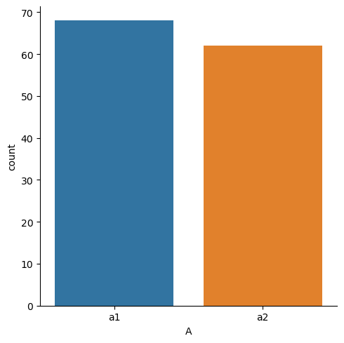

```python
sns.catplot(data = df01, x='A', kind='count')

plt.show()
```

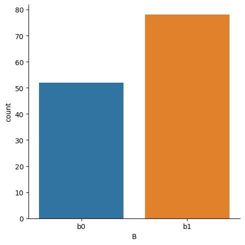

```python
sns.catplot(data = df01, x='B', kind='count')

plt.show()
```

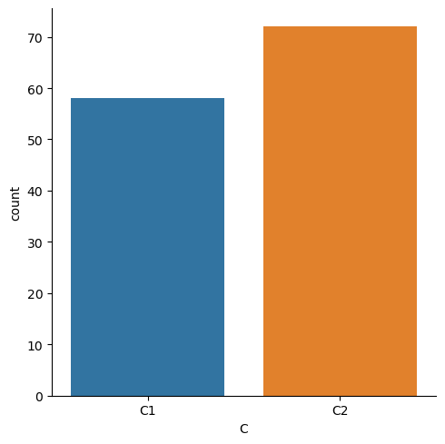

```python
sns.catplot(data = df01, x='C', kind='count')

plt.show()
```

## Histograms for DF01

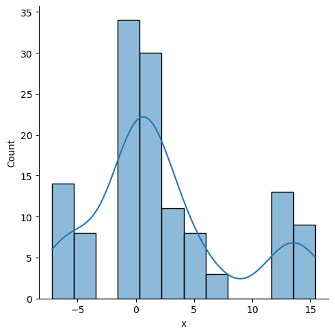

```python
sns.displot( data = df01, x='x', kind='hist', kde=True )

plt.show()
```

## Questions

**Do the categories of the NON-NUMERIC columns have similar counts?**

*No, the categories of the non-numeric columns don't have a similar count.*

# Exploration of Combination between 2 non-numeric columns

## Dodged Bar Charts for DF01

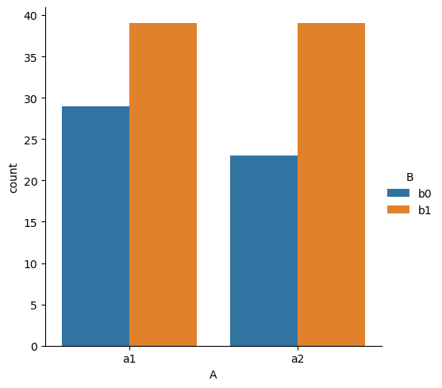

```python
sns.catplot( data = df01, x='A', hue='B', kind='count' )

plt.show()
```

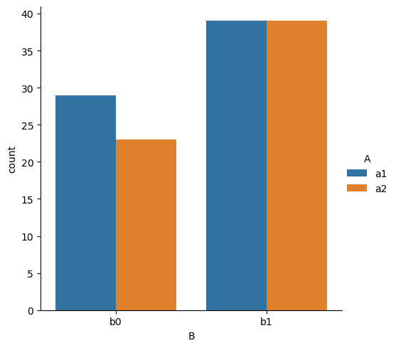

```python
sns.catplot( data = df01, x='B', hue='A', kind='count' )

plt.show()
```

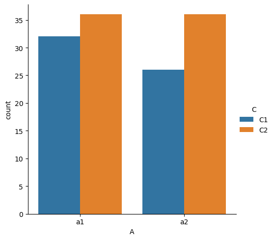

```python
sns.catplot( data = df01, x='A', hue='C', kind='count' )

plt.show()
```

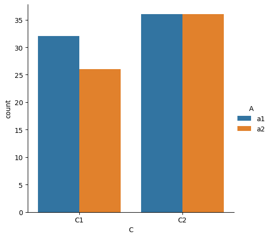

```python
sns.catplot( data = df01, x='C', hue='A', kind='count' )

plt.show()
```

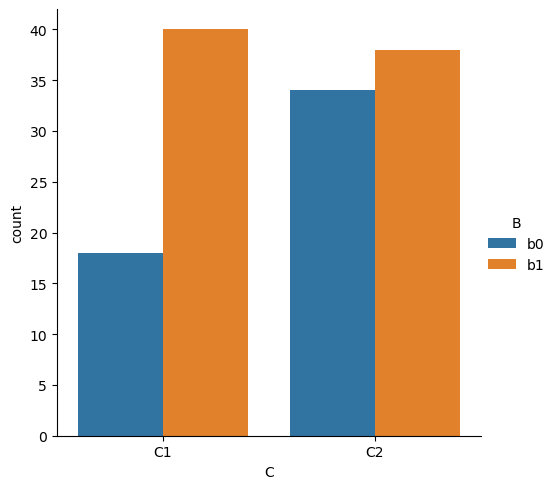

```python
sns.catplot( data = df01, x='C', hue='B', kind='count' )

plt.show()
```

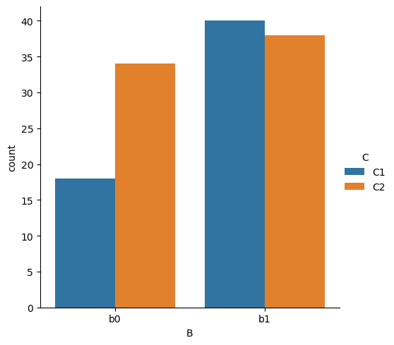

```python
sns.catplot( data = df01, x='B', hue='C', kind='count' )

plt.show()
```

## Heat Maps for DF01

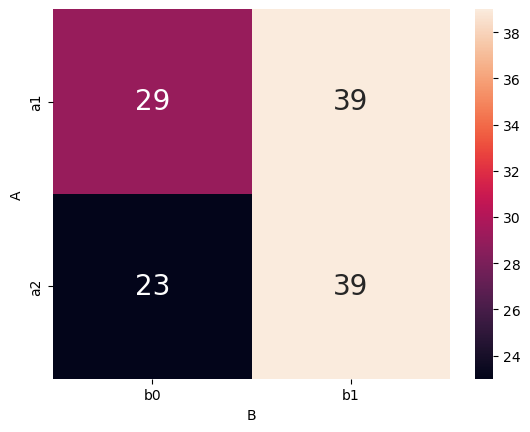

```python
fig, ax = plt.subplots()

sns.heatmap( pd.crosstab( df01.A, df01.B ), ax = ax,
             annot=True, annot_kws={'size': 20}, fmt='d')

plt.show()
```

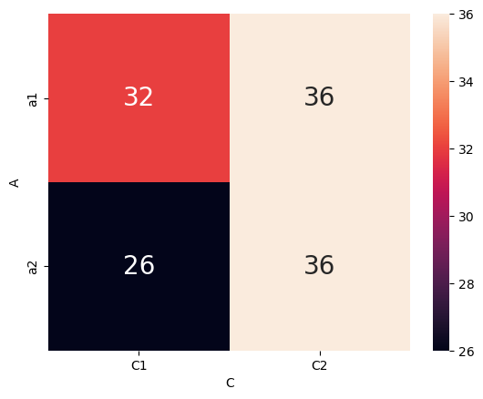

```python
fig, ax = plt.subplots()

sns.heatmap( pd.crosstab( df01.A, df01.C ), ax = ax,
             annot=True, annot_kws={'size': 20}, fmt='d')

plt.show()
```

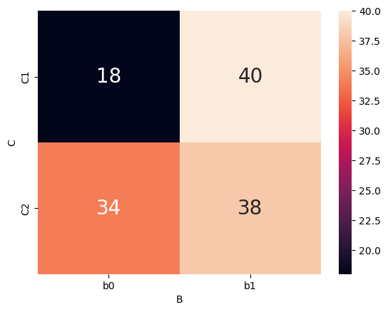

```python
fig, ax = plt.subplots()

sns.heatmap( pd.crosstab( df01.C, df01.B ), ax = ax,
             annot=True, annot_kws={'size': 20}, fmt='d')

plt.show()
```

## Questions

**Are there combinations between the 2 variables NOT present in the data?**

*There are no missing combinations*

**Which plot type was it easier to identify combinations that were NOT present?**

*It is ideally better to find the missing combinations in heat maps due to the numbers being displayed in the box. In this example, there are no missing combinations.*

# Categorical and Continuous Variables Relationships Exploration

## Conditional KDE Plots for DF01

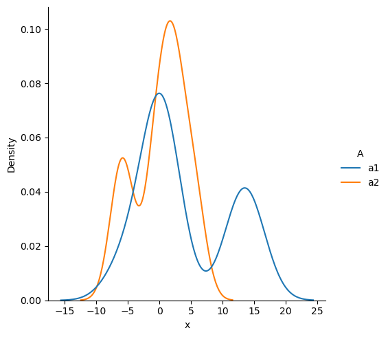

```python
sns.displot(data = df01, x='x', hue='A',
            common_norm=False, kind='kde')

plt.show()
```

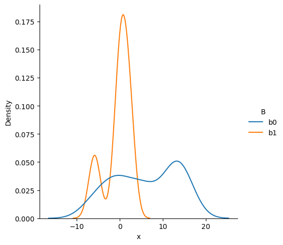

```python
sns.displot(data = df01, x='x', hue='B',
            common_norm=False, kind='kde')

plt.show()
```

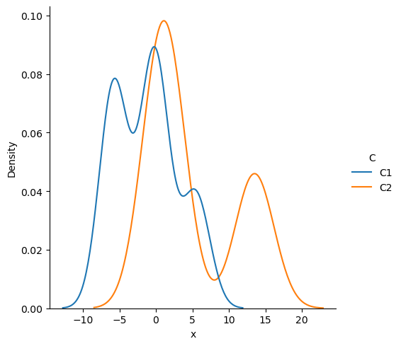

```python
sns.displot(data = df01, x='x', hue='C',
            common_norm=False, kind='kde')

plt.show()
```

## Boxplots for DF01

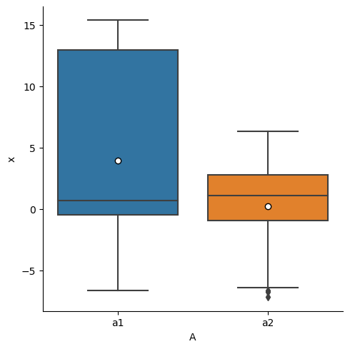

```python
sns.catplot(data = df01, x='A', y='x', kind='box',
            showmeans=True,
            meanprops={'marker': 'o', 'markerfacecolor': 'white', 'markeredgecolor': 'black'})

plt.show()
```

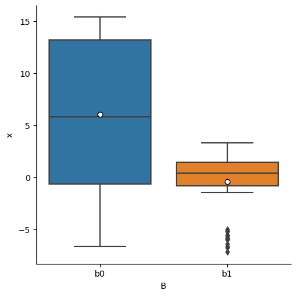

```python
sns.catplot(data = df01, x='B', y='x', kind='box',
            showmeans=True,
            meanprops={'marker': 'o', 'markerfacecolor': 'white', 'markeredgecolor': 'black'})

plt.show()
```

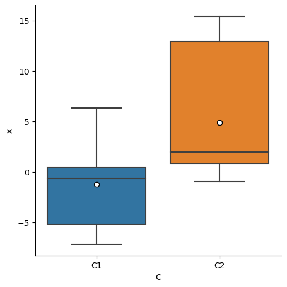

```python
sns.catplot(data = df01, x='C', y='x', kind='box',
            showmeans=True,
            meanprops={'marker': 'o', 'markerfacecolor': 'white', 'markeredgecolor': 'black'})

plt.show()
```

## Point Plots for DF01

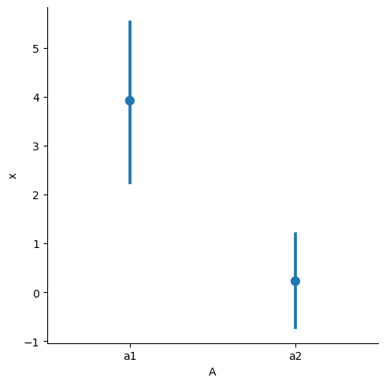

```python
sns.catplot( data = df01, x='A', y='x', kind='point', join=False )

plt.show()
```

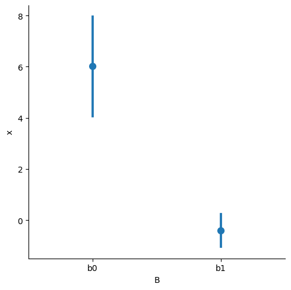

```python
sns.catplot( data = df01, x='B', y='x', kind='point', join=False )

plt.show()
```

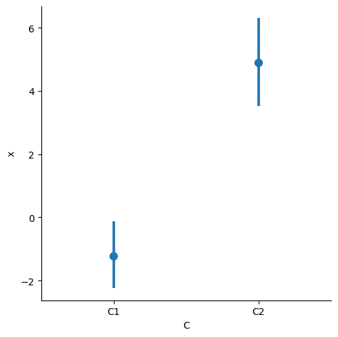

```python
sns.catplot( data = df01, x='C', y='x', kind='point', join=False )

plt.show()
```

## Questions

**Does the distributional SHAPE of a NUMERIC column appear to be different across the CATEGORIES of the NON-NUMERIC column?**

*Yes, the shape is different across the categories of the non-numeric column.*

**Does the MEDIAN of the NUMERIC column appear to be different across the CATEGORIES of the NON-NUMERIC column?**

*Yes, the median is different across the categories of the non-numeric column.*

**Does the VARIATION of the NUMERIC column appear to be different across the CATEGORIES of the NON-NUMERIC column?**

*Yes, the variation is different across the categories of the non-numeric column.*

**Are you confident that the MEAN of the NUMERIC column CHANGES across the CATEGORIES of the NON-NUMERIC column?**

*Yes, the mean changes across the categories of the non-numeric column.*

## Problem 02

Read in the `hw05_prob_02.csv` CSV file and assign it to the `df02` object.

Visually explore the `df02` object following **ALL** required actions listed previously.

You must add more code cells and markdown cells to complete this problem.

#### 02) - SOLUTION

```python
df02 = pd.read_csv('hw05_prob_02.csv')
```

```python
df02
```

|  | x | y | A | G |
| --- | --- | --- | --- | --- |
| 0 | 0.249430 | 1.226548 | 2.0 | 1 |
| 1 | -1.049282 | -1.100737 | NaN | 1 |
| 2 | -0.147525 | -0.679438 | NaN | 1 |
| 3 | 1.053127 | -0.475298 | NaN | 1 |
| 4 | 1.242744 | -1.060518 | 2.0 | 1 |
| ... | ... | ... | ... | ... |
| 363 | 0.357651 | -0.608975 | NaN | 14 |
| 364 | 0.235176 | 0.415023 | NaN | 14 |
| 365 | 0.283675 | -0.981750 | 2.0 | 14 |
| 366 | 0.929657 | -0.546980 | 2.0 | 14 |
| 367 | -1.068429 | 1.795239 | 2.0 | 14 |

368 rows × 4 columns

```python
df02.info()
```

```
<class 'pandas.core.frame.DataFrame'>
RangeIndex: 368 entries, 0 to 367
Data columns (total 4 columns):
 #   Column  Non-Null Count  Dtype
---  ------  --------------  -----
 0   x       368 non-null    float64
 1   y       352 non-null    float64
 2   A       347 non-null    float64
 3   G       368 non-null    int64
dtypes: float64(3), int64(1)
memory usage: 11.6 KB
```

```python
df02.nunique()
```

```
x    368
y    352
A      2
G     14
dtype: int64
```

```python
df02.isna().sum()
```

```
x     0
y    16
A    21
G     0
dtype: int64
```

# Marginal Behavior Exploration

## Bar Charts for DF02

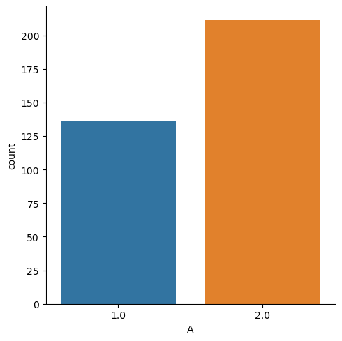

```python
sns.catplot(data = df02, x='A', kind='count')

plt.show()
```

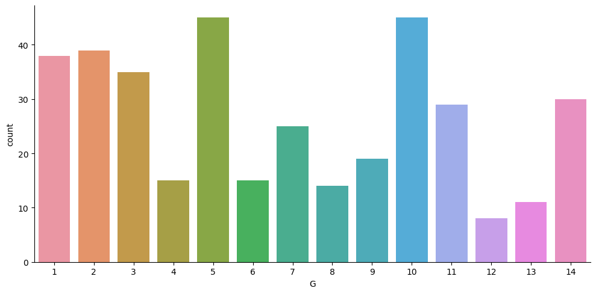

```python
sns.catplot(data = df02, x='G', kind='count', aspect=2)

plt.show()
```

## Histograms for DF02

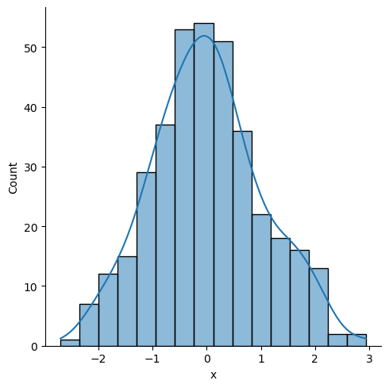

```python
sns.displot( data = df02, x='x', kind='hist', kde=True )

plt.show()
```

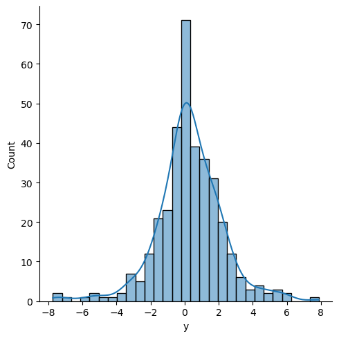

```python
sns.displot( data = df02, x='y', kind='hist', kde=True )

plt.show()
```

## Questions

**Do the categories of the NON-NUMERIC columns have similar counts?**

*No, the categories of the non-numeric columns don't have a similar count.*

**Do the histograms of the NUMERIC columns look roughly like bell curves?**

*Yes, the histograms look like bell-curves.*

# Exploration of Combination between 2 non-numeric columns

## Dodged Bar Charts for DF02

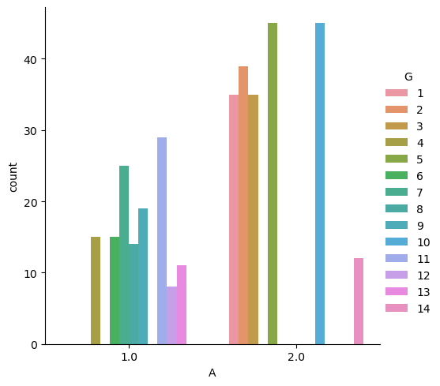

```python
sns.catplot( data = df02, x='A', hue='G', kind='count' )

plt.show()
```

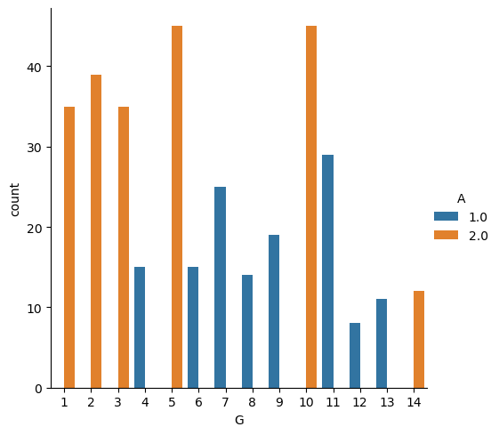

```python
sns.catplot( data = df02, x='G', hue='A', kind='count' )

plt.show()
```

## Heat Map for DF02

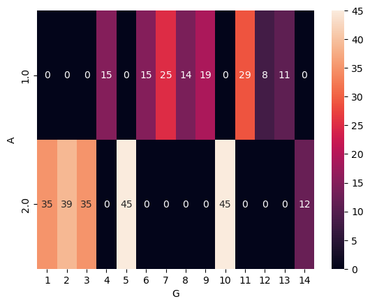

```python
fig, ax = plt.subplots()

sns.heatmap( pd.crosstab( df02.A, df02.G ), ax = ax,
             annot=True, annot_kws={'size': 10}, fmt='d')

plt.show()
```

## Questions

**Are there combinations between the 2 variables NOT present in the data?**

*Yes, there are a few combinations with missing data as shown with `0s` in the heat map.*

**Which plot type was it easier to identify combinations that were NOT present?**

*It is better to find the missing combinations in heat maps due to the numbers being displayed in the box. In this example, the missing combinations have `0` in the box and the coloring coding is the `darkest` color.*